# Relationship Pursuit Study

- Show All Code
- Hide All Code
- View Source

PSY 120L Reproducible Analysis Report

Author

Izzy Birkelund

Published

June 8, 2026

## About This Report

This report shows the coding used to create two 2 × 2 ANOVAs for a study on how relationship length and commitment readiness impact mate choice traits in romantic relationships.

## Setup and Software Environment

This code loads all of the packages used in the coding. We used tidyverse, psych, afex, and emmeans packages.

**Load Packages**

```r
library(tidyverse)  # data manipulation + plotting
library(psych)      # scale construction + reliability
library(afex)       # ANOVA models + effect sizes
library(emmeans)    # estimated marginal means + confidence intervals
```

## Data Source and Analysis Dataset

The sample consisted of 71 undergradauate participants randomly assigned to either the long-term or short-term condition.

### Import Dataset

```r
study_raw <- read_csv("data/relationship_pursuit_data.csv")
```

### Check Imported Dataset

```r
dim(study_raw)
```

```
[1] 71 35
```

```r
names(study_raw)
```

```
 [1] "ResponseId"           "DistributionChannel"  "consent"
 [4] "Long_Term_Traits_1"   "Long_Term_Traits_2"   "Long_Term_Traits_3"
 [7] "Long_Term_Traits_4"   "Long_Term_Traits_5"   "Long_Term_Traits_6"
[10] "Long_Term_Traits_7"   "Long_Term_Traits_8"   "Long_Term_Traits_9"
[13] "Long_Term_Traits_10"  "Short_Term_Traits_1"  "Short_Term_Traits_2"
[16] "Short_Term_Traits_3"  "Short_Term_Traits_4"  "Short_Term_Traits_5"
[19] "Short_Term_Traits_6"  "Short_Term_Traits_7"  "Short_Term_Traits_8"
[22] "Short_Term_Traits_9"  "Short_Term_Traits_10" "check"
[25] "Commit_1"             "Commit_2"             "Commit_3"
[28] "Commit_4"             "Commit_5"             "Commit_6"
[31] "Commit_7"             "Commit_8"             "age"
[34] "sex"                  "condition"
```

```r
head(study_raw)
```

```
# A tibble: 6 × 35
  ResponseId   DistributionChannel consent Long_Term_Traits_1 Long_Term_Traits_2
  <chr>        <chr>                 <dbl>              <dbl>              <dbl>
1 R_5DqGp4GTV… email                     1                 NA                 NA
2 R_5FjKOfBut… email                     1                  7                  7
3 R_12EXz22Ua… email                     1                 NA                 NA
4 R_10wYoD2Qc… anonymous                 1                 NA                 NA
5 R_3EiuvYYtL… anonymous                 1                  7                  7
6 R_1MSSHU33V… anonymous                 1                  7                  7
# ℹ 30 more variables: Long_Term_Traits_3 <dbl>, Long_Term_Traits_4 <dbl>,
#   Long_Term_Traits_5 <dbl>, Long_Term_Traits_6 <dbl>,
#   Long_Term_Traits_7 <dbl>, Long_Term_Traits_8 <dbl>,
#   Long_Term_Traits_9 <dbl>, Long_Term_Traits_10 <dbl>,
#   Short_Term_Traits_1 <dbl>, Short_Term_Traits_2 <dbl>,
#   Short_Term_Traits_3 <dbl>, Short_Term_Traits_4 <dbl>,
#   Short_Term_Traits_5 <dbl>, Short_Term_Traits_6 <dbl>, …
```

Our study collected data on trait choice for participants in the long-term and short-term condition, commitment readiness, sex, and age. Trait choice was collected in 10 questions and commitment readiness was collected in 8 questions. For participants in the long-term condition, they lack a response to the short-term traits, and participants in the short-term condition lack a response to the long-term traits. However, both groups were asked to rate the same traits.

### Create Analysis Dataset

```r
study_vars <- c(
     "condition", "check", "sex","age",

     "Commit_1","Commit_2","Commit_3","Commit_4",
     "Commit_5","Commit_6","Commit_7","Commit_8",

      "Long_Term_Traits_1","Long_Term_Traits_2","Long_Term_Traits_3",
      "Long_Term_Traits_4","Long_Term_Traits_5","Long_Term_Traits_6",
      "Long_Term_Traits_7","Long_Term_Traits_8","Long_Term_Traits_9",
      "Long_Term_Traits_10",

      "Short_Term_Traits_1","Short_Term_Traits_2","Short_Term_Traits_3",
      "Short_Term_Traits_4","Short_Term_Traits_5","Short_Term_Traits_6",
       "Short_Term_Traits_7","Short_Term_Traits_8","Short_Term_Traits_9",
      "Short_Term_Traits_10" # Short-term items

      )

study_data <- study_raw %>%
  select(all_of(study_vars)) %>%
  mutate(
    across(everything(), as.numeric)
  )
```

### Check Analysis Dataset

```r
length(study_vars)
```

```
[1] 32
```

```r
dim(study_data)
```

```
[1] 71 32
```

```r
names(study_data)
```

```
 [1] "condition"            "check"                "sex"
 [4] "age"                  "Commit_1"             "Commit_2"
 [7] "Commit_3"             "Commit_4"             "Commit_5"
[10] "Commit_6"             "Commit_7"             "Commit_8"
[13] "Long_Term_Traits_1"   "Long_Term_Traits_2"   "Long_Term_Traits_3"
[16] "Long_Term_Traits_4"   "Long_Term_Traits_5"   "Long_Term_Traits_6"
[19] "Long_Term_Traits_7"   "Long_Term_Traits_8"   "Long_Term_Traits_9"
[22] "Long_Term_Traits_10"  "Short_Term_Traits_1"  "Short_Term_Traits_2"
[25] "Short_Term_Traits_3"  "Short_Term_Traits_4"  "Short_Term_Traits_5"
[28] "Short_Term_Traits_6"  "Short_Term_Traits_7"  "Short_Term_Traits_8"
[31] "Short_Term_Traits_9"  "Short_Term_Traits_10"
```

## Variable Preparation

For our analysis, we looked at what condition participants were placed in, that they correctly answered the attention check, their sex and age, and the total items from the commitment and trait scales.

### Prepare Participant ID and Experimental Condition

```r
study_data <- study_data %>%
  mutate(
    id = row_number(),
    condition = factor(
      condition,
      levels = c(0, 1),
      labels = c("Short-Term", "Long-Term")
    ),
    sex = case_when(
      sex == 1 ~ "Male",
      sex == 2 ~ "Female",
      TRUE ~ NA_character_
    ),
    sex = factor(
      sex,
      levels = c("Female", "Male")
    )
  )
```

### Check Experimental Condition Coding

```r
study_data %>%
  count(condition) %>%
  knitr::kable(
    col.names = c("Condition", "n")
  )
```

| Condition | n |
| --- | --- |
| Short-Term | 34 |
| Long-Term | 35 |
| NA | 2 |

```r
study_data %>%
  count(sex) %>%
  knitr::kable(
    col.names = c("Sex", "n")
  )
```

| Sex | n |
| --- | --- |
| Female | 57 |
| Male | 8 |
| NA | 6 |

Overall, we had 71 participants.

### Check Prepared Analysis Dataset

```r
dim(study_data)
```

```
[1] 71 33
```

```r
names(study_data)
```

```
 [1] "condition"            "check"                "sex"
 [4] "age"                  "Commit_1"             "Commit_2"
 [7] "Commit_3"             "Commit_4"             "Commit_5"
[10] "Commit_6"             "Commit_7"             "Commit_8"
[13] "Long_Term_Traits_1"   "Long_Term_Traits_2"   "Long_Term_Traits_3"
[16] "Long_Term_Traits_4"   "Long_Term_Traits_5"   "Long_Term_Traits_6"
[19] "Long_Term_Traits_7"   "Long_Term_Traits_8"   "Long_Term_Traits_9"
[22] "Long_Term_Traits_10"  "Short_Term_Traits_1"  "Short_Term_Traits_2"
[25] "Short_Term_Traits_3"  "Short_Term_Traits_4"  "Short_Term_Traits_5"
[28] "Short_Term_Traits_6"  "Short_Term_Traits_7"  "Short_Term_Traits_8"
[31] "Short_Term_Traits_9"  "Short_Term_Traits_10" "id"
```

The data included what condition participants were randomly assigned to, an attention check, participant sex and age, 8 commitment items, 10 short-term items, 10 long-term items, and the participant ID.

### Reverse-Code Scale Items

Reverse code commitment and traits scores based on guidelines from the Commitment Readiness and Likert Scales. The Commitment Readiness Scale included four reverse-coded responses out of the total eight questions. Once reverse-coding was complete, higher scores indicated an overall higher commitment readiness. The Trait Likert Scale included five reverse-coded responses out of the total ten traits. Once reverse-coding was complete, higher scores indicated an overall higher self-reported importance of warmth traits.

```r
study_data <- study_data %>%
  mutate(

    Commit_2r  = 8 - Commit_2,
    Commit_4r  = 8 - Commit_4,
    Commit_6r = 8 - Commit_6,
    Commit_8r = 8 - Commit_8,

    Long_Term_Traits_3r  = 8 - Long_Term_Traits_3,
    Long_Term_Traits_4r  = 8 - Long_Term_Traits_4,
    Long_Term_Traits_6r = 8 - Long_Term_Traits_6,
    Long_Term_Traits_7r = 8 - Long_Term_Traits_7,
    Long_Term_Traits_10r = 8 - Long_Term_Traits_10,

    Short_Term_Traits_3r  = 8 - Short_Term_Traits_3,
    Short_Term_Traits_4r  = 8 - Short_Term_Traits_4,
    Short_Term_Traits_6r = 8 - Short_Term_Traits_6,
    Short_Term_Traits_7r = 8 - Short_Term_Traits_7,
    Short_Term_Traits_10r = 8 - Short_Term_Traits_10


  )
```

### Check Reverse Coding

```r
study_data %>%
  select(
    Commit_2, Commit_2r,
    Long_Term_Traits_3, Long_Term_Traits_3r,
    Short_Term_Traits_3, Short_Term_Traits_3r
  ) %>%
  head(10) %>%
  knitr::kable()
```

| Commit_2 | Commit_2r | Long_Term_Traits_3 | Long_Term_Traits_3r | Short_Term_Traits_3 | Short_Term_Traits_3r |
| --- | --- | --- | --- | --- | --- |
| 3 | 5 | NA | NA | 5 | 3 |
| 5 | 3 | 7 | 1 | NA | NA |
| 1 | 7 | NA | NA | 5 | 3 |
| 5 | 3 | NA | NA | 5 | 3 |
| 1 | 7 | 4 | 4 | NA | NA |
| 1 | 7 | 5 | 3 | NA | NA |
| 1 | 7 | NA | NA | 7 | 1 |
| 1 | 7 | 4 | 4 | NA | NA |
| 3 | 5 | NA | NA | 7 | 1 |
| 1 | 7 | 5 | 3 | NA | NA |

### Combine Trait Responses

```r
study_data <- study_data %>%
  mutate(
    trait_1  = coalesce(Long_Term_Traits_1,  Short_Term_Traits_1),
    trait_2  = coalesce(Long_Term_Traits_2,  Short_Term_Traits_2),
    trait_3  = coalesce(Long_Term_Traits_3r, Short_Term_Traits_3r),
    trait_4  = coalesce(Long_Term_Traits_4r, Short_Term_Traits_4r),
    trait_5  = coalesce(Long_Term_Traits_5,  Short_Term_Traits_5),
    trait_6  = coalesce(Long_Term_Traits_6r, Short_Term_Traits_6r),
    trait_7  = coalesce(Long_Term_Traits_7r, Short_Term_Traits_7r),
    trait_8  = coalesce(Long_Term_Traits_8,  Short_Term_Traits_8),
    trait_9  = coalesce(Long_Term_Traits_9,  Short_Term_Traits_9),
    trait_10 = coalesce(Long_Term_Traits_10r, Short_Term_Traits_10r)
  )
```

### Check Trait Variables

```r
study_data %>%
  select(
    condition,
    Long_Term_Traits_1,
    Short_Term_Traits_1,
    trait_1,
    Long_Term_Traits_3r,
    Short_Term_Traits_3r,
    trait_3
  ) %>%
  head(10) %>%
  knitr::kable()
```

| condition | Long_Term_Traits_1 | Short_Term_Traits_1 | trait_1 | Long_Term_Traits_3r | Short_Term_Traits_3r | trait_3 |
| --- | --- | --- | --- | --- | --- | --- |
| Short-Term | NA | 5 | 5 | NA | 3 | 3 |
| Long-Term | 7 | NA | 7 | 1 | NA | 1 |
| Short-Term | NA | 1 | 1 | NA | 3 | 3 |
| Short-Term | NA | 6 | 6 | NA | 3 | 3 |
| Long-Term | 7 | NA | 7 | 4 | NA | 4 |
| Long-Term | 7 | NA | 7 | 3 | NA | 3 |
| Short-Term | NA | 5 | 5 | NA | 1 | 1 |
| Long-Term | 7 | NA | 7 | 4 | NA | 4 |
| Short-Term | NA | 7 | 7 | NA | 1 | 1 |
| Long-Term | 5 | NA | 5 | 3 | NA | 3 |

### Create Scale Scores

We defined the Commitment Readiness Scale to include all eight responses, with half being reverse-coded. We then created the Warmth Scale to include all warmth traits, and the Attractiveness Scale to include all attractiveness traits.

```r
commit_items <- c(
  "Commit_1", "Commit_2r", "Commit_3", "Commit_4r",
  "Commit_5", "Commit_6r", "Commit_7", "Commit_8r"
)

warmth_items <- c(
  "trait_1", "trait_2", "trait_3", "trait_4", "trait_5"
)

attractiveness_items <- c(
  "trait_6", "trait_7", "trait_8", "trait_9", "trait_10"
)

study_data <- study_data %>%
  mutate(
    commit_scale = rowMeans(across(all_of(commit_items)), na.rm = TRUE),
    warmth_scale = rowMeans(across(all_of(warmth_items)), na.rm = TRUE),
    attractiveness_scale = rowMeans(across(all_of(attractiveness_items)), na.rm = TRUE)
  )
```

### Check Scale Scores

```r
study_data %>%
  select(
    commit_scale,
    warmth_scale,
    attractiveness_scale
  ) %>%
  summary()
```

```
  commit_scale    warmth_scale   attractiveness_scale
 Min.   :1.000   Min.   :1.600   Min.   :1.600
 1st Qu.:3.871   1st Qu.:3.550   1st Qu.:3.200
 Median :5.188   Median :4.800   Median :4.000
 Mean   :5.022   Mean   :4.394   Mean   :3.774
 3rd Qu.:6.281   3rd Qu.:5.400   3rd Qu.:4.400
 Max.   :7.000   Max.   :6.000   Max.   :5.400
 NA's   :3       NA's   :3       NA's   :3
```

```r
study_data %>%
  summarise(
    commit_scale_missing = mean(is.na(commit_scale)),
    warmth_scale_missing = mean(is.na(warmth_scale)),
    attractiveness_scale_missing = mean(is.na(attractiveness_scale))
  ) %>%
  knitr::kable()
```

| commit_scale_missing | warmth_scale_missing | attractiveness_scale_missing |
| --- | --- | --- |
| 0.0422535 | 0.0422535 | 0.0422535 |

Commitment scale: Min = 1; 1st Qu. = 3.871; Median = 5.188; Mean = 5.022; 3rd Qu. = 6.281; Max = 7.000

Warmth scale: Min = 1.6; 1st Qu. = 3.550; Median = 4.800; Mean = 4.394; 3rd Qu. = 5.400; Max = 6.000

Attractiveness scale: Min = 1.6; 1st Qu. = 3.200; Median = 4.000; Mean = 3.774; 3rd Qu. = 4.400; Max = 5.400

```r
commit_median <- median(study_data$commit_scale, na.rm = TRUE)

study_data <- study_data %>%
  mutate(
    commit_msplit = if_else(
      commit_scale <= commit_median,
      "Low Commitment",
      "High Commitment"
    ),
    commit_msplit = factor(
      commit_msplit,
      levels = c("Low Commitment", "High Commitment")
    )
  )

commit_median
```

```
[1] 5.1875
```

```r
study_data %>%
  count(commit_msplit) %>%
  knitr::kable(
    col.names = c("Commitment Group", "n")
  )
```

| Commitment Group | n |
| --- | --- |
| Low Commitment | 34 |
| High Commitment | 34 |
| NA | 3 |

### Check Scale Reliability

We checked the reliability of our scales using Cronbach’s alpha and McDonald’s omega.

```r
commit_item_df <- study_data %>%
  select(all_of(commit_items))

warmth_item_df <- study_data %>%
  select(all_of(warmth_items))

attractiveness_item_df <- study_data %>%
  select(all_of(attractiveness_items))

commit_alpha <- psych::alpha(commit_item_df)
commit_omega <- psych::omega(commit_item_df, plot = FALSE)

warmth_alpha <- psych::alpha(warmth_item_df)
warmth_omega <- psych::omega(warmth_item_df, plot = FALSE)

attractiveness_alpha <- psych::alpha(attractiveness_item_df)
```

```
Some items ( trait_8 trait_9 ) were negatively correlated with the first principal component and
probably should be reversed.
To do this, run the function again with the 'check.keys=TRUE' option
```

```r
attractiveness_omega <- psych::omega(attractiveness_item_df, plot = FALSE)

reliability_table <- tibble(
  scale = c("Commitment", "Warmth", "Attractiveness"),
  alpha = c(
    commit_alpha$total$raw_alpha,
    warmth_alpha$total$raw_alpha,
    attractiveness_alpha$total$raw_alpha
  ),
  omega = c(
    commit_omega$omega.tot,
    warmth_omega$omega.tot,
    attractiveness_omega$omega.tot
  )
)

reliability_table %>%
  mutate(
    alpha = round(alpha, 2),
    omega = round(omega, 2)
  ) %>%
  knitr::kable(
    col.names = c("Scale", "Cronbach's alpha", "McDonald's omega")
  )
```

| Scale | Cronbach’s alpha | McDonald’s omega |
| --- | --- | --- |
| Commitment | 0.94 | 0.97 |
| Warmth | 0.77 | 0.87 |
| Attractiveness | 0.49 | 0.83 |

Commitment: alpha = 0.94; omega = 0.97

Warmth: alpha = 0.77, omega = 0.87

Attractiveness: alpha = 0.49, omega = 0.83

## Descriptive Statistics

Descriptive statistics for the commitment, warmth, and attractiveness scales.

### Scale Score Descriptives

```r
# Descriptive statistics for continuous scale variables
psych::describe(
  study_data %>%
    select(
      commit_scale,
      warmth_scale,
      attractiveness_scale
    )
) %>%
  knitr::kable(digits = 2)
```

|  | vars | n | mean | sd | median | trimmed | mad | min | max | range | skew | kurtosis | se |
| --- | --- | --- | --- | --- | --- | --- | --- | --- | --- | --- | --- | --- | --- |
| commit_scale | 1 | 68 | 5.02 | 1.56 | 5.19 | 5.14 | 1.76 | 1.0 | 7.0 | 6.0 | -0.54 | -0.47 | 0.19 |
| warmth_scale | 2 | 68 | 4.39 | 1.22 | 4.80 | 4.49 | 1.19 | 1.6 | 6.0 | 4.4 | -0.69 | -0.79 | 0.15 |
| attractiveness_scale | 3 | 68 | 3.77 | 0.89 | 4.00 | 3.80 | 0.89 | 1.6 | 5.4 | 3.8 | -0.38 | -0.58 | 0.11 |

Commitment: *n* = 68; *mean* = 5.02; *sd* = 1.56; *median* = 5.19; *trimmed* = 5.14; *mad* = 1.76; *max* = 7; *range* = 6; *skew* = -0.54; *kurtosis* = -0.47; *se* = 0.19

Warmth: *n* = 68; *mean* = 4.39; *sd* = 1.22; *median* = 4.80; *trimmed* = 4.49; *mad* = 1.19; *max* = 6; *range* = 4.4; *skew* = -0.69; *kurtosis* = -0.79; *se* = 0.15

### Sample Composition by Age and Gender

```r
study_data %>%
  summarise(
    mean_age = round(mean(age, na.rm = TRUE), 2),
    sd_age = round(sd(age, na.rm = TRUE), 2),
    min_age = min(age, na.rm = TRUE),
    max_age = max(age, na.rm = TRUE)
  ) %>%
  knitr::kable(
    col.names = c("Mean Age", "SD Age", "Minimum Age", "Maximum Age")
  )
```

| Mean Age | SD Age | Minimum Age | Maximum Age |
| --- | --- | --- | --- |
| 21.26 | 1.14 | 19 | 27 |

```r
study_data %>%
  count(sex) %>%
  mutate(percent = round(100 * n / sum(n), 1)) %>%
  knitr::kable(
    col.names = c("Sex", "n", "Percent")
  )
```

| Sex | n | Percent |
| --- | --- | --- |
| Female | 57 | 80.3 |
| Male | 8 | 11.3 |
| NA | 6 | 8.5 |

Our mean age was 21.26, the standard deviation was 1.14, the minimum age was 19, and the maximum age was 27.

## Primary Analyses

Our first ANOVA was a 2 (Condition: Long-term vs. Short-term) × 2 (Commitment Level: Low vs. High) between-subjects ANOVA on warmth trait preference for romantic partners. Our second ANOVA was a 2 (Condition: Long-term vs. Short-term) × 2 (Commitment Level: Low vs. High) between-subjects ANOVA on attractiveness trait preference for romantic partners.

### Warmth Model: Condition × Commitment Group

```r
a1_warmth_commit <- afex::aov_ez(
  id = "id",
  dv = "warmth_scale",
  between = c("condition", "commit_msplit"),
  data = study_data
)

a1_warmth_commit
```

```
Anova Table (Type 3 tests)

Response: warmth_scale
                   Effect    df  MSE         F   ges p.value
1               condition 1, 64 0.76 67.01 ***  .512   <.001
2           commit_msplit 1, 64 0.76      0.69  .011    .408
3 condition:commit_msplit 1, 64 0.76      0.00 <.001    .996
---
Signif. codes:  0 '***' 0.001 '**' 0.01 '*' 0.05 '+' 0.1 ' ' 1
```

### Estimated Means for Warmth: Condition × Commitment Group

```r
emmeans(a1_warmth_commit, ~ condition)
```

```
 condition  emmean    SE df lower.CL upper.CL
 Short-Term   3.50 0.152 64     3.20     3.80
 Long-Term    5.24 0.148 64     4.94     5.53

Results are averaged over the levels of: commit_msplit
Confidence level used: 0.95
```

```r
emmeans(a1_warmth_commit, ~ commit_msplit)
```

```
 commit_msplit   emmean    SE df lower.CL upper.CL
 Low Commitment    4.46 0.149 64     4.16     4.76
 High Commitment   4.28 0.150 64     3.98     4.58

Results are averaged over the levels of: condition
Confidence level used: 0.95
```

```r
emmeans(a1_warmth_commit, ~ condition * commit_msplit)
```

```
 condition  commit_msplit   emmean    SE df lower.CL upper.CL
 Short-Term Low Commitment    3.59 0.205 64     3.18     4.00
 Long-Term  Low Commitment    5.33 0.218 64     4.89     5.76
 Short-Term High Commitment   3.41 0.225 64     2.96     3.86
 Long-Term  High Commitment   5.15 0.200 64     4.75     5.55

Confidence level used: 0.95
```

### Attractiveness Model: Condition × Commitment Group

```r
a2_attractiveness_commit <- afex::aov_ez(
  id = "id",
  dv = "attractiveness_scale",
  between = c("condition", "commit_msplit"),
  data = study_data
)

a2_attractiveness_commit
```

```
Anova Table (Type 3 tests)

Response: attractiveness_scale
                   Effect    df  MSE         F   ges p.value
1               condition 1, 64 0.52 37.17 ***  .367   <.001
2           commit_msplit 1, 64 0.52      2.10  .032    .153
3 condition:commit_msplit 1, 64 0.52      0.00 <.001    .959
---
Signif. codes:  0 '***' 0.001 '**' 0.01 '*' 0.05 '+' 0.1 ' ' 1
```

### Estimated Means for Attractiveness: Condition × Commitment Group

```r
emmeans(a2_attractiveness_commit, ~ condition)
```

```
 condition  emmean    SE df lower.CL upper.CL
 Short-Term   3.22 0.125 64     2.97     3.48
 Long-Term    4.29 0.122 64     4.05     4.53

Results are averaged over the levels of: commit_msplit
Confidence level used: 0.95
```

```r
emmeans(a2_attractiveness_commit, ~ commit_msplit)
```

```
 commit_msplit   emmean    SE df lower.CL upper.CL
 Low Commitment    3.88 0.123 64     3.64     4.13
 High Commitment   3.63 0.124 64     3.38     3.88

Results are averaged over the levels of: condition
Confidence level used: 0.95
```

```r
emmeans(a2_attractiveness_commit, ~ condition * commit_msplit)
```

```
 condition  commit_msplit   emmean    SE df lower.CL upper.CL
 Short-Term Low Commitment    3.36 0.169 64     3.02     3.69
 Long-Term  Low Commitment    4.41 0.179 64     4.05     4.77
 Short-Term High Commitment   3.09 0.185 64     2.72     3.46
 Long-Term  High Commitment   4.17 0.165 64     3.84     4.50

Confidence level used: 0.95
```

## Figures

We created two figures to show the interaction between commitment readiness and relationship-length condition.

### Warmth Model: Condition × Commitment Group Interaction Plot

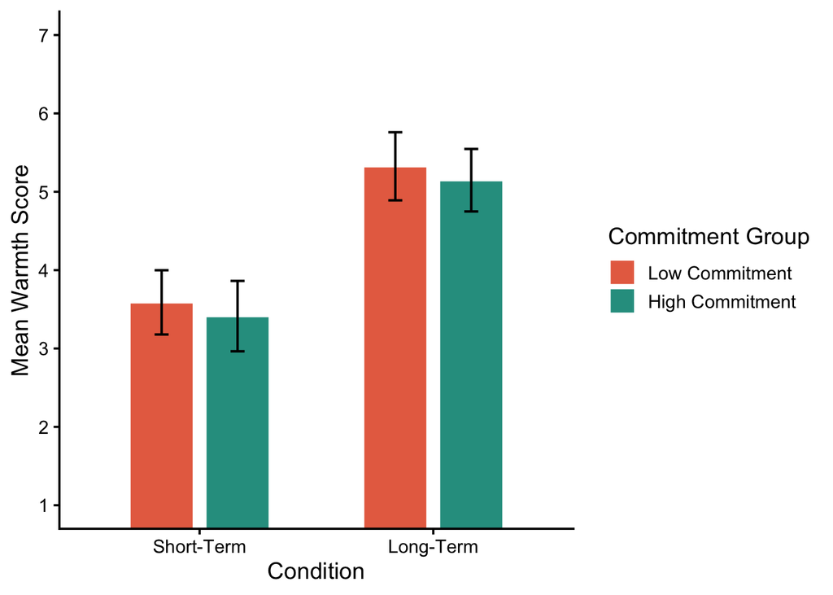

```r
p_warmth_condition_commit_bar <- ggplot(
  as.data.frame(emmeans(a1_warmth_commit, ~ condition * commit_msplit)),
  aes(
    x = condition,
    y = emmean,
    fill = commit_msplit
  )
) +
  geom_col(
    position = position_dodge(width = 0.65),
    width = 0.55,
    color = "white"
  ) +
  geom_errorbar(
    aes(
      ymin = lower.CL,
      ymax = upper.CL
    ),
    position = position_dodge(width = 0.65),
    width = 0.12,
    linewidth = 0.7
  ) +
  labs(
    x = "Condition",
    y = "Mean Warmth Score",
    fill = "Commitment Group"
  ) +
  scale_fill_manual(
    values = c(
      "Low Commitment" = "#E76F51",
      "High Commitment" = "#2A9D8F"
    )
  ) +
  scale_y_continuous(
    breaks = seq(1, 7, 1)
  ) +
  coord_cartesian(
    ylim = c(1, 7)
  ) +
  theme_classic(
    base_size = 14
  )

p_warmth_condition_commit_bar
```

Those in the long-term condition, regardless of commitment level, placed a significantly higher rate of importance on warmth traits than those in the short-term condition.

### Attractiveness Model: Condition × Commitment Group Interaction Plot

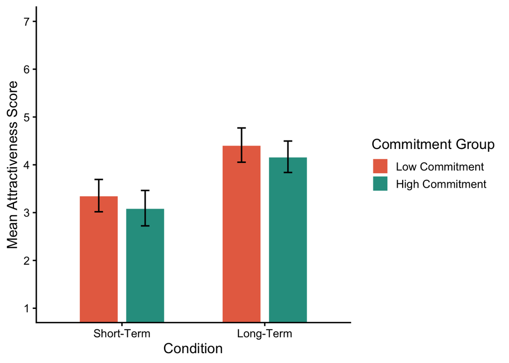

```r
p_attractiveness_condition_commit_bar <- ggplot(
  as.data.frame(emmeans(a2_attractiveness_commit, ~ condition * commit_msplit)),
  aes(
    x = condition,
    y = emmean,
    fill = commit_msplit
  )
) +
  geom_col(
    position = position_dodge(width = 0.65),
    width = 0.55,
    color = "white"
  ) +
  geom_errorbar(
    aes(
      ymin = lower.CL,
      ymax = upper.CL
    ),
    position = position_dodge(width = 0.65),
    width = 0.12,
    linewidth = 0.7
  ) +
  labs(
    x = "Condition",
    y = "Mean Attractiveness Score",
    fill = "Commitment Group"
  ) +
  scale_fill_manual(
    values = c(
      "Low Commitment" = "#E76F51",
      "High Commitment" = "#2A9D8F"
    )
  ) +
  scale_y_continuous(
    breaks = seq(1, 7, 1)
  ) +
  coord_cartesian(
    ylim = c(1, 7)
  ) +
  theme_classic(
    base_size = 14
  )

p_attractiveness_condition_commit_bar
```

Those in the long-term condition, regardless of commitment level, also showed a higher rated importance of attractiveness traits than those in the short-term condition.

### Export Figures

```r
if (!dir.exists("figures")) {
  dir.create("figures")
}

ggsave(
  filename = "figures/warmth_condition_commitment_interaction_plot.svg",
  plot = p_warmth_condition_commit_bar,
  width = 7,
  height = 5
)

ggsave(
  filename = "figures/attractiveness_condition_commitment_interaction_plot.svg",
  plot = p_attractiveness_condition_commit_bar,
  width = 7,
  height = 5
)
```

The plots displays model-estimated mean warmth or attractiveness scores across relationship-length condition, shown separately for low and high commitment readiness.